# 36-315 Lab 03

SOLUTIONS

Due September 18, 2021 (12:00pm) on Gradescope

# Problem 1: Chi-Square Tests for Independence (30 points)

In this lab we’ll use data from the Twitter Airline Sentiment dataset, which can be found [here](https://raw.githubusercontent.com/zjbranson/315Fall2021/master/Tweets.csv). When reading in the data, we will assign it to a variable called `airline_tweets`. This same dataset will come up on Homework3.

First we’ll read in the dataset and add some additional variables (code provided below).

```r
library(tidyverse)
library(reshape2)

#  Read in data
airline_tweets <- read.csv("https://raw.githubusercontent.com/zjbranson/315Fall2021/master/Tweets.csv")

date_time <- colsplit(airline_tweets$tweet_created, " ", c("date", "time", "zone"))

#  Add start_date variable to airline_tweets, and a bunch of other variables
airline_tweets <- mutate(airline_tweets,
                    start_date = as.Date(date_time$date, format = "%Y-%m-%d"),
                    hour_of_day = as.integer(substr(date_time$time, 1, 2)),
                    am_or_pm = ifelse(hour_of_day < 12, "AM", "PM"),
                    day_of_week = weekdays(start_date),
                    weekend = ifelse(day_of_week %in% c("Saturday", "Sunday"),
                                     "Weekend", "Weekday"),
                    tweet_length = ifelse(nchar(as.character(text)) > 100, "Long", "Short"))
```

This dataset contains information about Tweets made about airlines (e.g., Delta, Southwest, etc.) Most of these Tweets are made while someone is waiting to board a flight. This problem focuses on the following variables:

- `day_of_week`: The day the Tweet was made (Monday, Tuesday, etc.)
- `am_or_pm`: Whether the Tweet was made during an AM (morning) or PM (afternoon/evening) time.
- `tweet_length`: Whether a Tweet is more than 100 characters (“Long”) or less than 100 characters (“Short”).
1. (10pts) Create a contingency table of the `day_of_week` and `am_or_pm` variables using the `table()` function, and store this in an object called `tab1a`. Then, test to see if these two variables are independent using a chi-square test with the following code: `chisq.test(tab1a)`.

*First, here is the chi-square test code:*

```r
tab1a = table(airline_tweets$day_of_week, airline_tweets$am_or_pm)
chisq.test(tab1a)
```

```
##
##  Pearson's Chi-squared test
##
## data:  tab1a
## X-squared = 985.52, df = 6, p-value < 2.2e-16
```

- What is the value of the observed chi-square test statistic?

*We see it is 985.52.*

- What is the p-value of the test?

*We see it is quite small; less than $2.2 \cdot 10^{-16}$.*

- What is your conclusion – is there enough evidence to reject the null hypothesis that the two variables are independent?

*Yes, there is enough evidence to reject the null hypothesis; since the p-value is below $\alpha = 0.05$, we reject the null hypothesis that the `day_of_week` and `am_or_pm` variables are independent, thereby concluding that they are dependent.*

2. (5pts) Do you think the conclusion you made in Part A makes sense in the context of the problem? Explain your answer in 1-2 sentences.

*In the previous part, we concluded that, for different days of the week, there will be different distributions of AM/PM airline Tweets, and vice versa. This makes sense, since people are probably more likely to Tweet at an airline while they are at an airport. For instance, Monday AMs and Sunday PMs are particularly busy times for travel, but Wednesday AMs and Wednesday PMs are not particularly busy times for travel. Thus, there are some days when we expect many (or few) AM Tweets and some days when we expect many (or few) PM Tweets.*

3. (5pts) Repeat Part A, but this time, re-order the variables in the table function. Do the test results change? Does this make sense? Why or why not?

*First, here’s the code with the variables reversed:*

```r
tab1c = table(airline_tweets$am_or_pm, airline_tweets$day_of_week)
chisq.test(tab1c)
```

```
##
##  Pearson's Chi-squared test
##
## data:  tab1c
## X-squared = 985.52, df = 6, p-value < 2.2e-16
```

*The test results do not change when we re-order the variables in the table function. This makes sense because the chi-square test statistic and degrees of freedom do not depend on the order of the variables. Another way to think about it is: The null hypothesis for Part A is that day-of-week and AM-or-PM are independent, and the null hypothesis here is that AM-or-PM and day-of-week are independent; these hypotheses are equivalent.*

4. (10pts) Repeat Part A, but this time, test the independence of the `am_or_pm` and `tweet_length` variables. Interpret the result **in the context of the problem**. Do you think this result makes sense, given what we might expect about the length of different tweets?

*First, here is the chi-squared test:*

```r
tab1d = table(airline_tweets$am_or_pm, airline_tweets$tweet_length)
chisq.test(tab1d)
```

```
##
##  Pearson's Chi-squared test with Yates' continuity correction
##
## data:  tab1d
## X-squared = 0.555, df = 1, p-value = 0.4563
```

*Here we test the null hypothesis that the Tweet length (long or short) and time of day (AM or PM) of airline Tweets are independent. To test this, we perform a chi-square test at the $\alpha = 0.05$ significance level, and we obtain a p-value of 0.4563. Since $p>0.05$, we fail to reject the null hypothesis that airline Tweet length and time of day are independent. That is, for either time of day (AM or PM), the distribution of Tweet length may be the same. This makes sense, since we wouldn’t expect the length of Tweets to depend on time of day.*

# Problem 2: Making and Interpreting Mosaic Plots (40 points)

There is no official, `ggplot()`-sanctioned code for creating mosaic plots in `ggplot()`. Instead, we’ll just use the base `R` function `mosaicplot()`. (Note that, for all assignments, you are free to use base `R` functions instead of `ggplot` functions if you’d like, unless otherwise specified.)

In Problem 1, we tested independence among three variables: `day_of_week`, `am_or_pm`, and `tweet_length`. In this problem, we’ll make mosaic plots for these variables, and compare our findings here to our findings in Problem 1.

1. (15pts) For this part, the goal is to make a mosaic plot with `am_or_pm` and `day_of_week`. The syntax for the `mosaicplot()` function is `mosaicplot(x = ?)`. Answer the following questions:
- What kind of object should `x` be set to in `mosaicplot()`? **Hint**: Look at the help documentation for `mosaicplot()`. You used this exact same object when working with the chi-squared test in Problem 1.

*When we look at the help documentation for `mosaicplot()`, and look under Arguments, we see that `x` is described as “a contingency table.” So, we should input a contingency table into `x`. (Note that we used contingency tables throughout Problem 1.)*

- Now that you know what to set `x` to within `mosaicplot()`, make a mosaic plot of `am_or_pm` and `day_of_week`. Pick whichever order you’d like to display these variables. For now, keep the rectangles within the mosaic plot colored as gray.

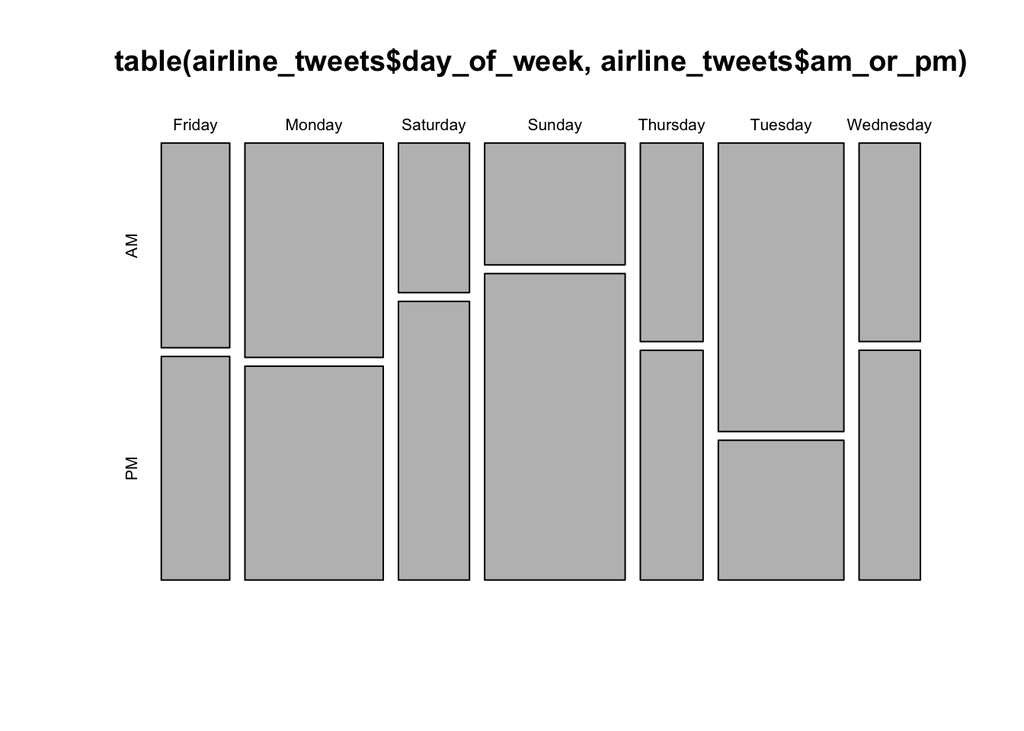

```r
mosaicplot(table(airline_tweets$day_of_week, airline_tweets$am_or_pm))
```

- After you’ve made your mosaic plot: What do the widths of the rectangles in the mosaic plot correspond to? What do the heights of the rectangles in the mosaic plot correspond to?

*The widths are proportional to the number of tweets on each day of the week - i.e., the marginal distribution of day of the week. Meanwhile, the heights are proportional to the conditional distribution of AM/PM tweets given day of the week. Note that this answer would be different if we switched the order of `day_of_week` and `am_or_pm` within `table()`.*

2. (5pts) As we discussed in class, it can be helpful to color the rows of a mosaic plot. For this part, copy-and-paste the mosaic plot you made in Part B, and color the rows with colors of your choice. To do this, within `mosaicplot()`, set `col` equal to a vector of colors, where the number of colors is equal to the number of rows. For example, if my mosaic plot had three rows, I could set `col = c("red", "blue", "green")` to color one row as red, another as blue, and another as green. For this part, all you need to do is turn in your colored mosaic plot.

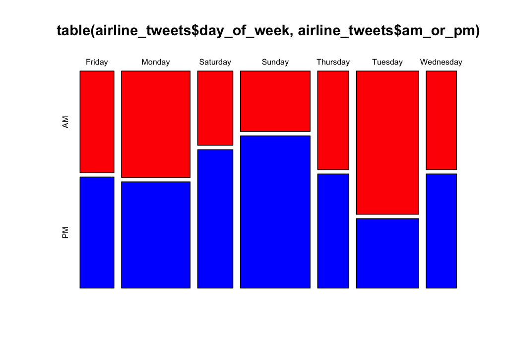

```r
mosaicplot(table(airline_tweets$day_of_week, airline_tweets$am_or_pm),
           col = c("red", "blue"))
```

3. (5pts) Now for this part, we will make two mosaic plots:
- A mosaic plot of `am_or_pm` and `day_of_week`, colored by Pearson residuals.

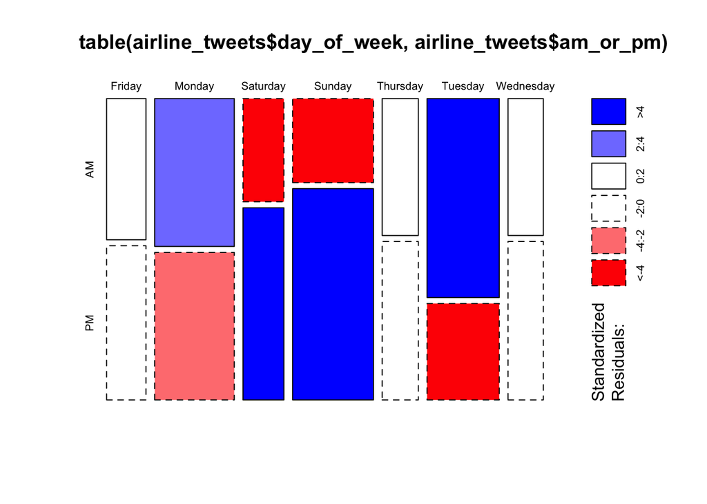

```r
mosaicplot(table(airline_tweets$day_of_week, airline_tweets$am_or_pm),
           shade = TRUE)
```

- A mosaic plot of `am_or_pm` and `tweet_length`, colored by Pearson residuals.

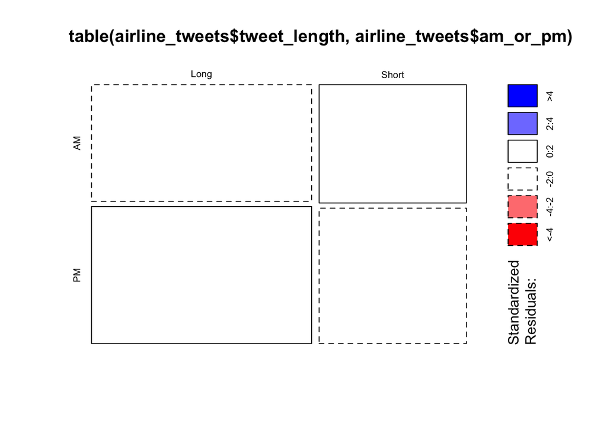

```r
mosaicplot(table(airline_tweets$tweet_length, airline_tweets$am_or_pm),
           shade = TRUE)
```

To color by Pearson residuals, instead of setting `col` within `mosaicplot()`, you set `shade = TRUE`. For this part, all you need to do is create both plots, which should involve mostly copy-and-pasting your code from Part B.

4. (15pts) Now we will interpret the mosaic plots you made in Part C. As we discussed in class this week, for the mosaic plots colored by the Pearson residuals, if any of the residuals are greater than 2 or less than -2, we can conclude that there is evidence against the null hypothesis of independence. A very positive residual denotes higher counts than we would expect under the null, and a very negative residual denotes lower counts than we would expect under the null. Given this, answer the following questions:
- For the mosaic plot showing `am_or_pm` and `day_of_week`: Which cells (or combinations of categories) have observed counts that are significantly higher than what we would expect under independence (if any)? Which have observed counts that are significantly lower than what we would expect under independence (if any)?

*The combinations Monday/AM, Saturday/PM, Sunday/PM, and Tuesday/AM have observed counts that are significantly higher than what we would expect under independence. Monday/PM, Saturday/AM, Sunday/AM, and Tuesday/PM have observed counts that are significantly lower than what would be expected under independence. Note the symmetry in these conclusions - this will happen when you have a binary categorical variable like AM/PM (think about why).*

- For the mosaic plot showing `am_or_pm` and `tweet_length`: Which cells (or combinations of categories) have observed counts that are significantly higher than what we would expect under independence (if any)? Which have observed counts that are significantly lower than what we would expect under independence (if any)?

*Because the mosaic plot is all white, it appears that there are no observed counts that are significantly higher or lower than what we would expect under independence.*

- Do the mosaic plots in Part C yield the same conclusions as the chi-square tests from Problem 1? State yes or no, and explain in 1-2 sentences.

*Yes, the mosaic plots in Problem 2 suggest the same conclusions as the chi-square tests from Problem 1.*

*In the plot involving `am_or_pm` and `day_of_week`, many of the cells are red or blue; this provides evidence against the null hypothesis that day of the week and time of day of airline tweets are independent, and we made the same conclusion by rejecting the null hypothesis when we ran the analogous chi-squared test in Problem 1. Meanwhile, in the plot involving `am_or_pm` and `tweet_length`, all cells are white, which does not provide any evidence against the null hypothesis that the distributions of Tweet length and time of day are independent for airline Tweets; this agrees with what we found in Problem 1, where we failed to reject the null hypothesis that tweet length and time of the day are independent by running the chi-squared test.*

# Problem 3: Considering Conditional Distributions for 2D Bar Plots (30 points)

In Lab2 we made stacked bar plots and facetted bar plots, and discussed how we can use those plots to describe marginal distributions. Now we’re going to do the same thing here, but to describe conditional distributions.

1. (10pts) First, make a stacked bar plot that involves the variables `am_or_pm` and `day_of_week`. In particular, make your stacked bar plot such that you think it’s easiest to see the conditional distribution of `am_or_pm` given `day_of_week`. Then, use your plot to describe the condtiional distribution of `am_or_pm` given `day_of_week`. In particular: For which days do AM tweets seem to be more common, for which days do PM tweets seem to be more common, and for which days do they seem about equal? (**Hint**: If you can’t remember how to make a stacked bar plot, either look back at Lab2 or ask for help.)

*First, here is our stacked bar plot:*

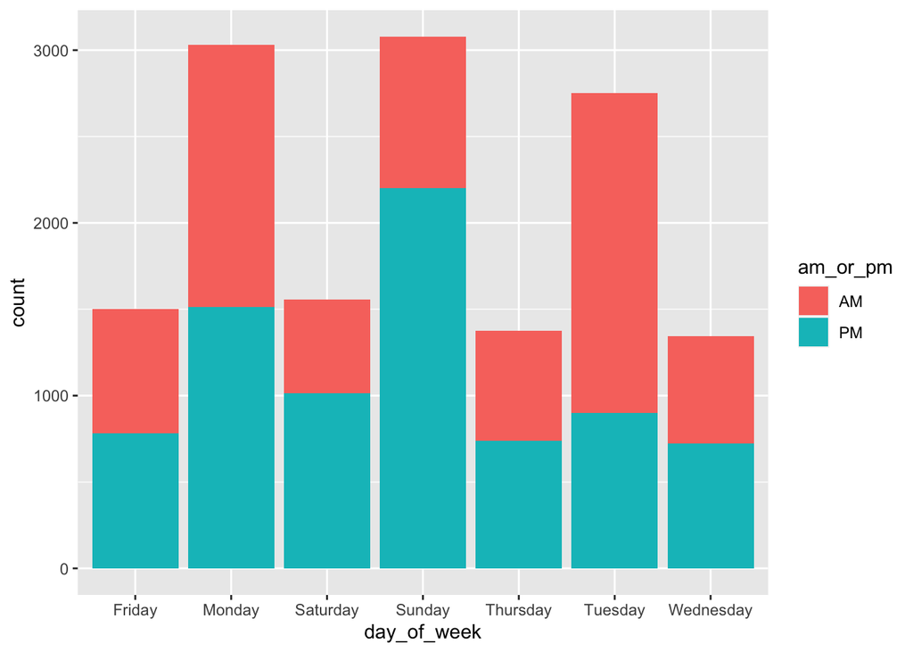

```r
ggplot(airline_tweets, aes(x = day_of_week, fill = am_or_pm)) + geom_bar()
```

*Note that we set `x = day_of_week` such that we can look at each bar to “fix” `day_of_week`, thereby allowing us to see the conditional distribution of `am_or_pm` for a given `day_of_week`. First, AM and PM tweets seem to be (roughly) equally common on Mondays, Wednesdays, Thursdays, and Fridays. Meanwhile, AM tweets seem to be more common for Tuesdays, and PM tweets seem to be more common for Saturdays and Sundays.*

2. (10pts) When thinking about the conditional distribution of `am_or_pm` given `day_of_week`, it’s helpful to remember that `am_or_pm` is a binary variable. Thus, for any fixed `day_of_week`, the distribution of `am_or_pm` will just correspond to the proportion of AM tweets and the proportion of PM tweets. Because there are seven days of the week, the conditional distribution of `am_or_pm` given `day_of_week` can therefore be characterized by seven *pairs* of proportions, where each pair adds up to 1.

A function we’ve seen previously that can be useful for computing conditional distributions is the `prop.table()` function. As a reminder, this function takes in a `table()` object, and reports back proportions. First, consider the following table of proportions:

```r
prop.table(table(airline_tweets$am_or_pm, airline_tweets$day_of_week))
```

```
##
##          Friday     Monday   Saturday     Sunday   Thursday    Tuesday
##   AM 0.04897541 0.10368852 0.03715847 0.05983607 0.04357923 0.12663934
##   PM 0.05348361 0.10341530 0.06919399 0.15047814 0.05040984 0.06133880
##
##       Wednesday
##   AM 0.04255464
##   PM 0.04924863
```

Note that the proportions add up to 1. This table displays the *joint* distribution of `am_or_pm` and `day_of_week`, because it tells us the proportion of subjects (in this case, tweets) that belong to every joint combination of `am_or_pm` and `day_of_week`. Now, given this, answer the following questions:

- Copy-and-paste the above `prop.table()` code, but write `margin = 1` within `prop.table()`. You should get back a table of proportions where the rows add up to 1. Does this table display (a) the conditional distribution of `am_or_pm` given `day_of_week`, or (b) the conditional distribution of `day_of_week` given `am_or_pm`? Explain your answer in 1-2 sentences.

```r
prop.table(table(airline_tweets$am_or_pm, airline_tweets$day_of_week), margin = 1)
```

```
##
##          Friday     Monday   Saturday     Sunday   Thursday    Tuesday
##   AM 0.10590842 0.22422452 0.08035451 0.12939439 0.09423929 0.27385524
##   PM 0.09949174 0.19237611 0.12871665 0.27992376 0.09377382 0.11410419
##
##       Wednesday
##   AM 0.09202363
##   PM 0.09161372
```

*This shows the conditional distribution of `day_of_week` given `am_or_pm`. Within a certain row, we are “fixing” whether we are looking at AM or PM tweets—then, there are seven proportions that add up to 1, which correspond to the proportions of each day of the week. In other words, the top row shows the conditional distribution of `day_of_week` given AM tweets, and the bottom row does the same given PM tweets.*

- Copy-and-paste the above `prop.table()` code, but write `margin = 2` within `prop.table()`. You should get back a table of proportions where the columns add up to 1. Does this table display (a) the conditional distribution of `am_or_pm` given `day_of_week`, or (b) the conditional distribution of `day_of_week` given `am_or_pm`? Explain your answer in 1-2 sentences.

```r
prop.table(table(airline_tweets$am_or_pm, airline_tweets$day_of_week), margin = 2)
```

```
##
##         Friday    Monday  Saturday    Sunday  Thursday   Tuesday Wednesday
##   AM 0.4780000 0.5006596 0.3493899 0.2845080 0.4636628 0.6736919 0.4635417
##   PM 0.5220000 0.4993404 0.6506101 0.7154920 0.5363372 0.3263081 0.5364583
```

*This shows the conditional distribution of `am_or_pm` given `day_of_week`. Within a certain column, we are “fixing” the day of the week—then, there are two proportions that add up to 1, which correspond to the proportions of AM and PM tweets. For example, the first column shows the conditional distribution of `am_or_pm` for Fridays, and the last column does the same for Wednesdays.*

3. (10pts) Now, make a facetted bar plot that involves the variables `am_or_pm` and `day_of_week`. In particular, make your facetted bar plot such that you think it’s easiest to see the conditional distribution of `day_of_week` given `am_or_pm`. After you’ve made your plot, rotate the axis labels 90 degrees by “adding” `+ theme(axis.text.x = element_text(angle = 90))` to your `ggplot()` code. (You might find that this makes it easier to read the axis.) Then, use your plot to describe the condtiional distribution of `day_of_week` given `am_or_pm`. (**Hint**: If you can’t remember how to make a facetted bar plot, either look back at Lab2 or ask for help.)

*First, here is our facetted bar plot:*

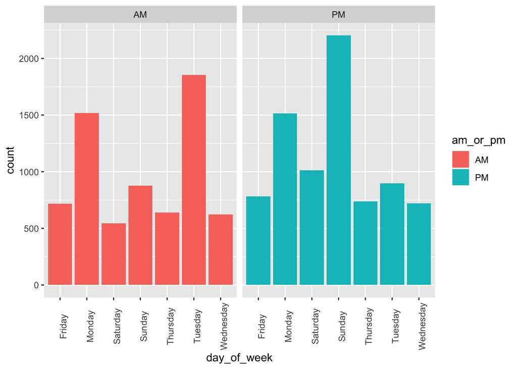

```r
ggplot(airline_tweets, aes(x = day_of_week)) + geom_bar(aes(fill = am_or_pm)) + facet_grid(~am_or_pm) + theme(axis.text.x = element_text(angle = 90))
```

*Note that each facet shows a distribution of `day_of_week`; in particular, the left facet shows the conditional distribution of `day_of_week` given AM tweets, and the right does the same for PM tweets. Thus, it’s very easy to see the desired conditional distribution.*